# LAD calibration

## UCLouvain

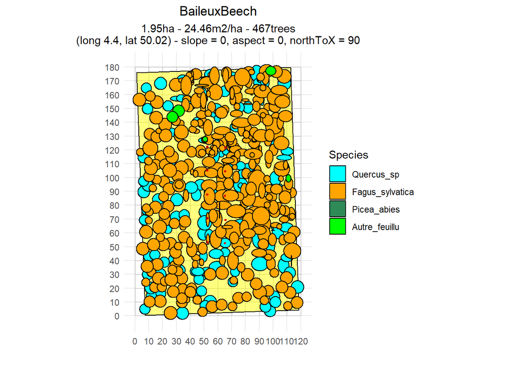

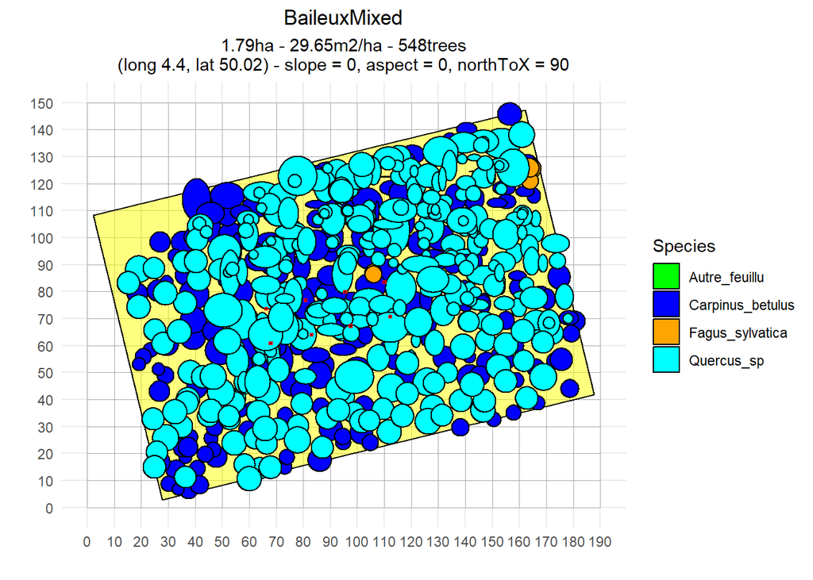

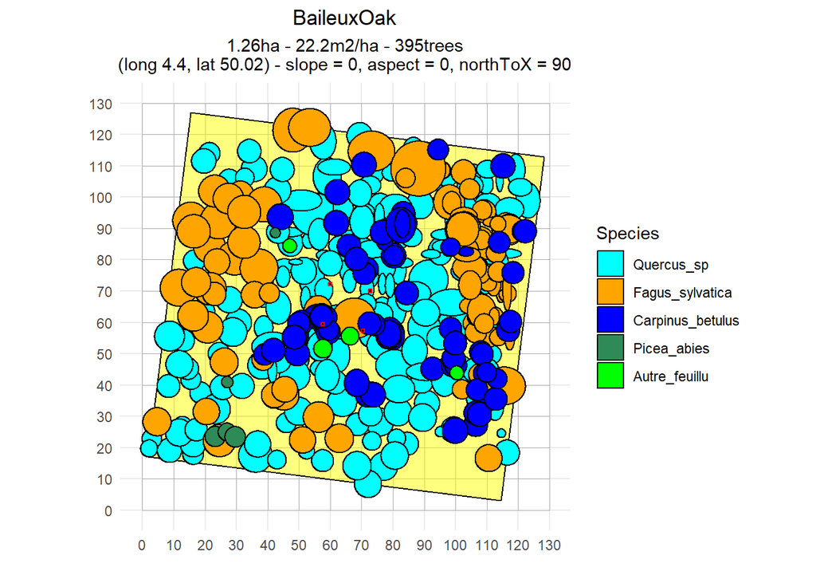

# Preliminary analysis

As a preliminary analysis, we tried to fit a mean LAD value for each sensor of each site. To do so, we run the SamsaraLight model on each stand by fixing the same crown LAD values of each tree, and for each sensor, we computed the residuals between the estimated PACL value on the virtual sensor, and the observed PACL on the field for this sensor. We did so for 5000 values of LAD from 0.001 to 5. By doing so, we could find for each sensor the LAD that minimizes the residuals.

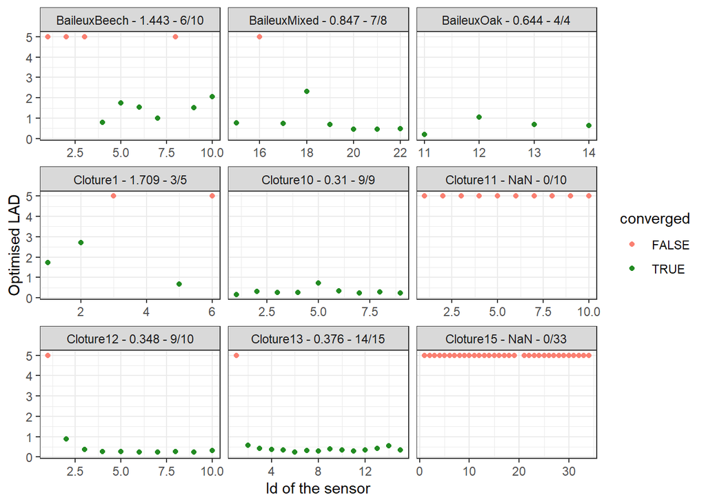

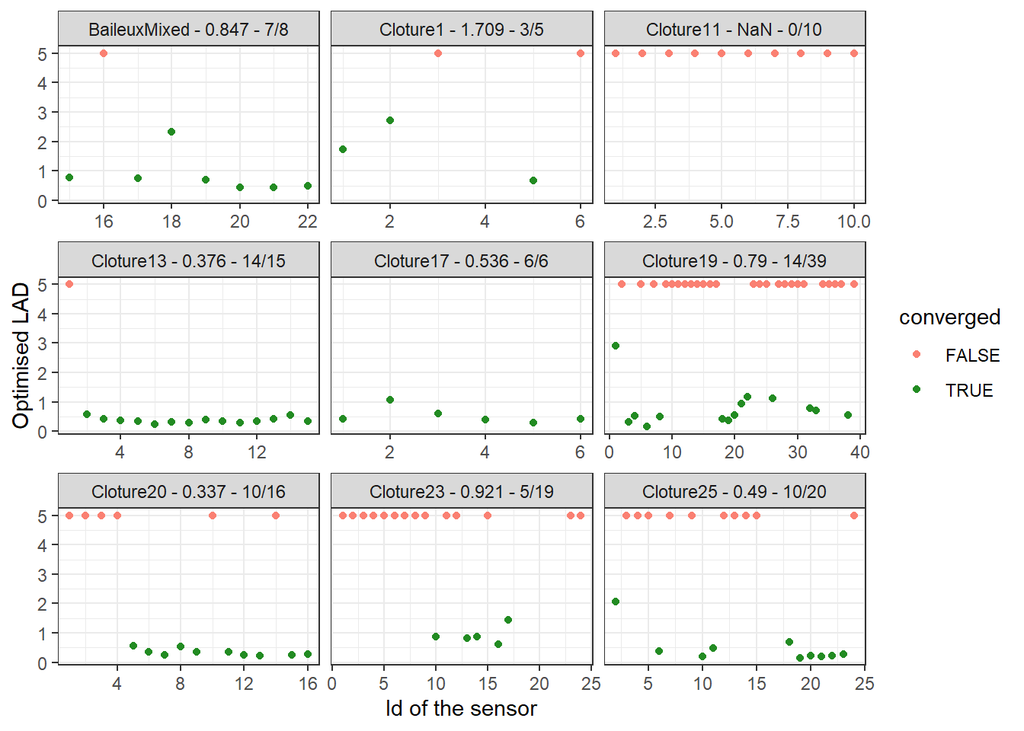

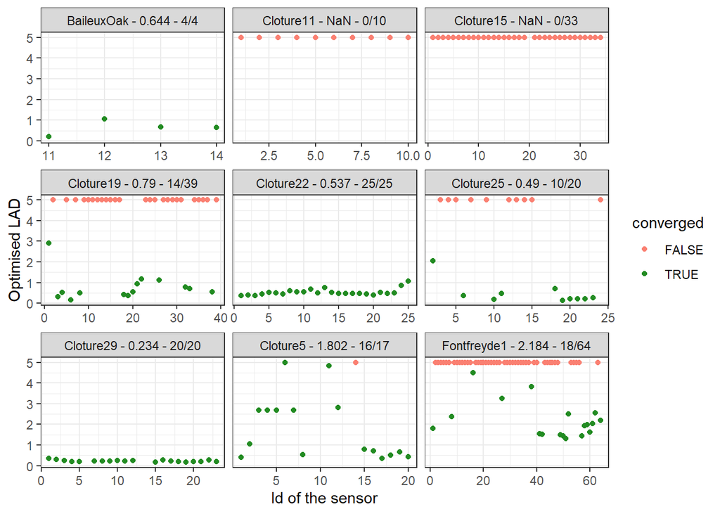

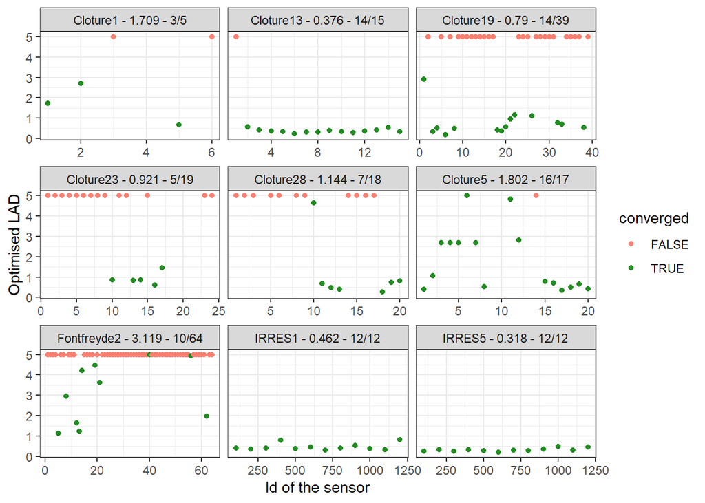

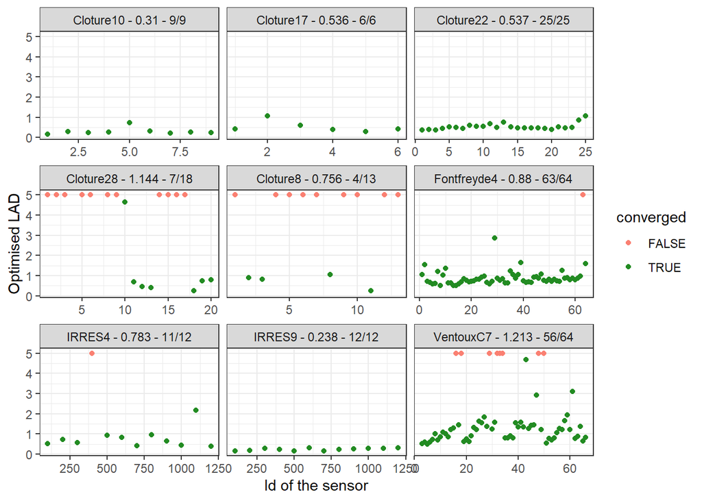

Many sensors did not converged (i.e. best fitting LAD was 5 as the residuals function showed an asymptotic form). Indeed, we could increase as much as we want the trees’s LAD, the estimated PACL could not decrease as much as the observed one. PACL is principally linked to the crown geometries, and secondary by the crown LAD. Thus, there are two cases where crown LAD did not influence PACL: (i) for open stands, where the high light on the ground comes principally from unobstructed rays, (ii) for highly crowded stands, where the very low light on the ground comes from the high number of intercepted crowns. Another reason could be linked to the wrong representation of leaves and crown above the sensor, where a simple branch can obstruct the sensor in the field where we considered a simple crown shape that result in incapabilities of representing such a light obstruction with the SamsaraLight model. Consequently, we remove the sensors that did not converged (465/1121 sensors), leading to remove consequently 3 sites where all sensors did not converged: Cloture11, Cloture15, Cloture2.

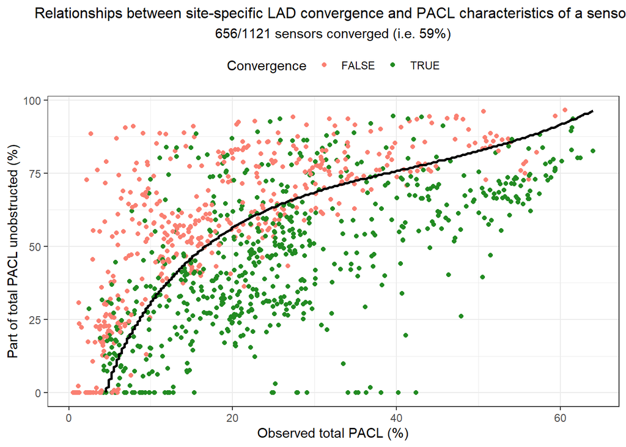

The mean LAD over all sensors that converged was about 0.928

# Bayesian calibration

```
##    id_simu id_exp n_chains n_iterations id_mod filter_sensors species_specific
## 1      1_1      1        1         5000      1          FALSE            FALSE
## 2      1_2      1        1         5000      2           TRUE            FALSE
## 3      2_1      2        1        20000      1           TRUE            FALSE
## 4      2_2      2        1        20000      2           TRUE             TRUE
## 5      2_3      2        1        20000      3           TRUE            FALSE
## 6      2_4      2        1        20000      4           TRUE             TRUE
## 7      2_5      2        1        20000      5           TRUE            FALSE
## 8      2_6      2        1        20000      6           TRUE             TRUE
## 9      2_7      2        1        20000      7           TRUE            FALSE
## 10     2_8      2        1        20000      8           TRUE             TRUE
##    site_rd_effect origin_rd_effect dbh_effect compet_effect n_analysis
## 1           FALSE            FALSE      FALSE         FALSE        500
## 2           FALSE            FALSE      FALSE         FALSE        500
## 3           FALSE            FALSE      FALSE         FALSE       1000
## 4           FALSE            FALSE      FALSE         FALSE       1000
## 5            TRUE            FALSE      FALSE         FALSE       1000
## 6            TRUE            FALSE      FALSE         FALSE       1000
## 7           FALSE             TRUE      FALSE         FALSE       1000
## 8           FALSE             TRUE      FALSE         FALSE       1000
## 9            TRUE             TRUE      FALSE         FALSE       1000
## 10           TRUE             TRUE      FALSE         FALSE       1000
```

## Experience 1: observe the effect of sensors filtering

### Computation time

```
##   id_mod n_chains n_iterations filter_sensors time_hours
## 1      1        1         5000          FALSE   3.372476
## 2      2        1         5000           TRUE   2.706250
```

### Compare models and LAD predictions

```
##   id_simu filter_sensors lad_qt025 lad_median lad_qt975
## 1     1_1          FALSE 1.2252147  1.3492099 1.4938880
## 2     1_2           TRUE 0.6656822  0.6994571 0.7338606
```

```
##   id_simu filter_sensors  mae_qt025 mae_median  mae_qt975 rmse_qt025
## 1     1_1          FALSE 0.08162803 0.08169704 0.08185108 0.10268344
## 2     1_2           TRUE 0.05962874 0.05975579 0.06033674 0.07624968
##   rmse_median rmse_qt975
## 1  0.10276032 0.10292941
## 2  0.07627568 0.07647321
```

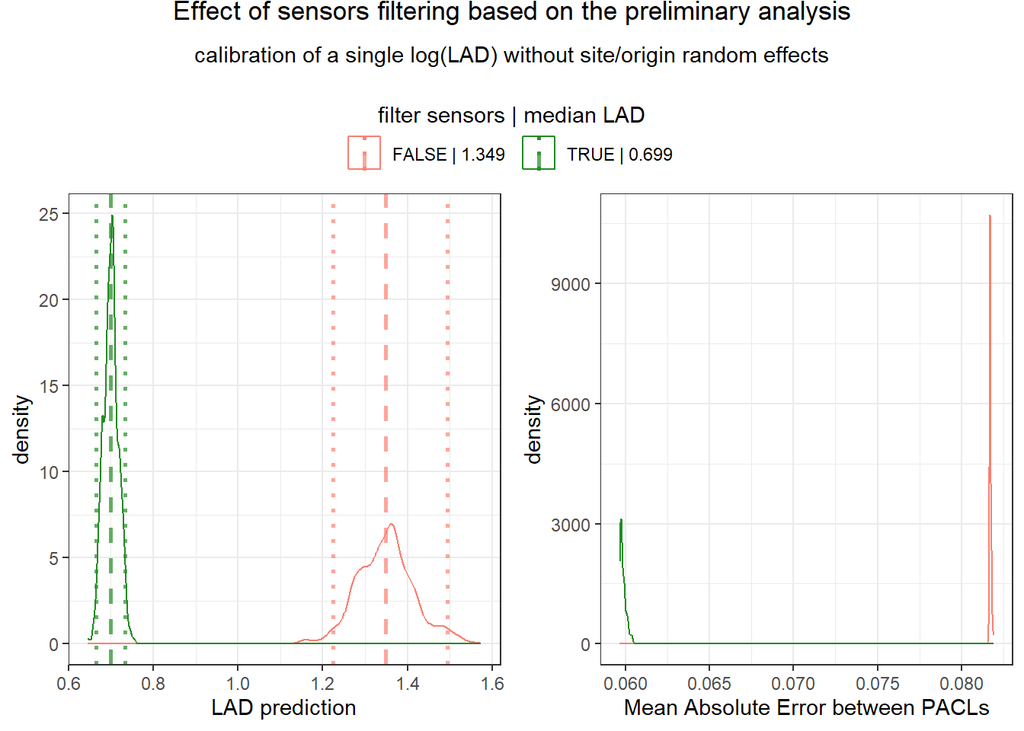

### Observe convergence

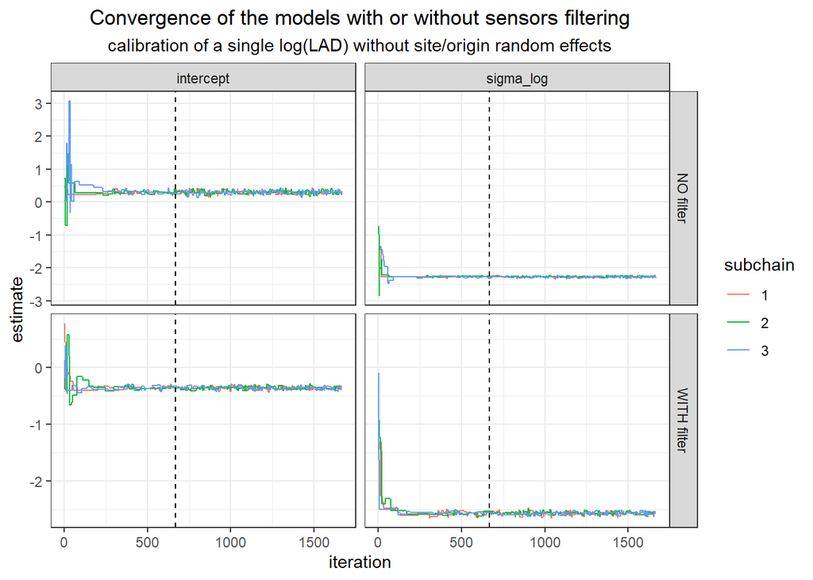

## Experience 2: evaluate the neccessity to include random effects

A first Bayesian approach would be to also fit a mean LAD value on the sensors that converged with the previous method, by considering a hierarchical random effect (site into origin, mandatory according to the structure our our dataset).

The model can be written as: $LAD_{p} = a_{0} + a_{0,p} + \epsilon$, where $a_{0}$ is the LAD intercept and $a_{0,p}$ is a random hierarchical site effect, nested within an origin effect (4 origins of the plots within UCLouvain, INRAe, Cloture and IRRES).

### Computation time

```
##   id_mod n_chains n_iterations species_specific site_rd_effect origin_rd_effect
## 1      1        1        20000            FALSE          FALSE            FALSE
## 2      2        1        20000             TRUE          FALSE            FALSE
## 3      3        1        20000            FALSE           TRUE            FALSE
## 4      4        1        20000             TRUE           TRUE            FALSE
## 5      5        1        20000            FALSE          FALSE             TRUE
## 6      6        1        20000             TRUE          FALSE             TRUE
## 7      7        1        20000            FALSE           TRUE             TRUE
## 8      8        1        20000             TRUE           TRUE             TRUE
##   time_hours
## 1   10.82797
## 2   10.86761
## 3   10.84726
## 4   10.84948
## 5   10.82423
## 6   11.67727
## 7   10.84147
## 8   11.13030
```

### Compare models

```
##   id_simu species_specific site_rd_effect origin_rd_effect  mae_qt025
## 1     2_1            FALSE          FALSE            FALSE 0.05962881
## 2     2_2             TRUE          FALSE            FALSE 0.05264182
## 3     2_3            FALSE           TRUE            FALSE 0.03697073
## 4     2_4             TRUE           TRUE            FALSE 0.03674217
## 5     2_5            FALSE          FALSE             TRUE 0.05187797
## 6     2_6             TRUE          FALSE             TRUE 0.04938371
## 7     2_7            FALSE           TRUE             TRUE 0.03710419
## 8     2_8             TRUE           TRUE             TRUE 0.03784678
##   mae_median  mae_qt975 rmse_qt025 rmse_median rmse_qt975               looic
## 1 0.05975034 0.06020425 0.07625224  0.07628164 0.07643856  -1511.4 (SE 39.78)
## 2 0.05301884 0.05365351 0.06828175  0.06857173 0.06919517 -1641.36 (SE 43.62)
## 3 0.03808208 0.03862282 0.05036516  0.05113081 0.05127214 -2005.47 (SE 55.32)
## 4 0.03765119 0.03809580 0.04913965  0.04973726 0.05054516 -2040.04 (SE 55.03)
## 5 0.05204787 0.05223897 0.06797451  0.06809589 0.06831678 -1656.66 (SE 44.73)
## 6 0.04982558 0.05039956 0.06484755  0.06532084 0.06600650  -1702.18 (SE 45.2)
## 7 0.03746429 0.03769253 0.04978088  0.05033249 0.05046798 -2025.26 (SE 53.76)
## 8 0.03856015 0.03902325 0.05032125  0.05118989 0.05185495 -2001.63 (SE 49.06)
```

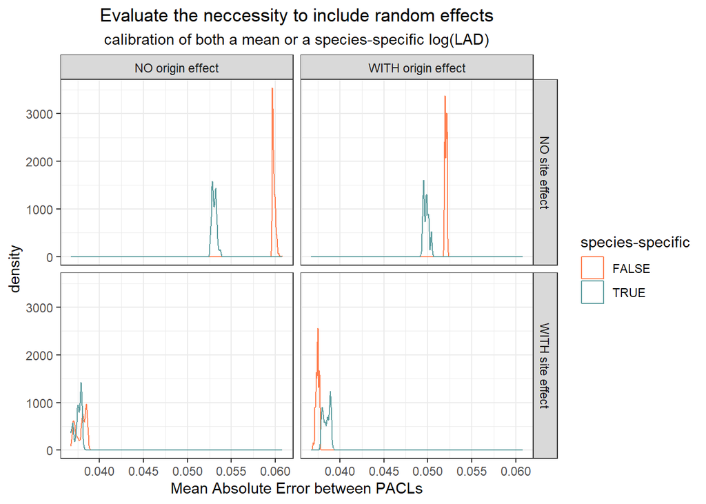

### LAD predictions

```
##   species site_rd_effect origin_rd_effect lad_qt025 lad_median lad_qt975
## 1    mean          FALSE            FALSE 0.6707550  0.6989385 0.7296829
## 2    mean          FALSE             TRUE 0.5504556  0.6750808 1.0012997
## 3    mean           TRUE            FALSE 0.6507164  0.6826624 0.7273544
## 4    mean           TRUE             TRUE 0.5323910  0.5431563 0.5589910
```

```
##                  species site_rd_effect origin_rd_effect lad_qt025 lad_median
## 1  Pseudotsuga_menziesii          FALSE            FALSE 0.2754949  0.3108958
## 2          Larix_decidua          FALSE            FALSE 0.2695163  0.3552764
## 3        Fagus_sylvatica          FALSE            FALSE 0.3558276  0.4034259
## 4            Picea_abies          FALSE            FALSE 0.5138019  0.5744647
## 5             Quercus_sp          FALSE            FALSE 0.5701679  0.6406561
## 6       Carpinus_betulus          FALSE            FALSE 0.4004714  0.7004827
## 7       Pinus_sylvestris          FALSE            FALSE 0.7743893  0.8290632
## 8             Abies_alba          FALSE            FALSE 0.7397762  1.2136280
## 9       Carpinus_betulus          FALSE             TRUE 0.2666448  0.4907836
## 10       Fagus_sylvatica          FALSE             TRUE 0.5317550  0.6163830
## 11 Pseudotsuga_menziesii          FALSE             TRUE 0.6011227  0.6984844
## 12      Pinus_sylvestris          FALSE             TRUE 0.5792218  0.7547381
## 13            Abies_alba          FALSE             TRUE 0.5301598  0.7908201
## 14         Larix_decidua          FALSE             TRUE 0.6176541  0.7975647
```

[output cut: 51 more lines]

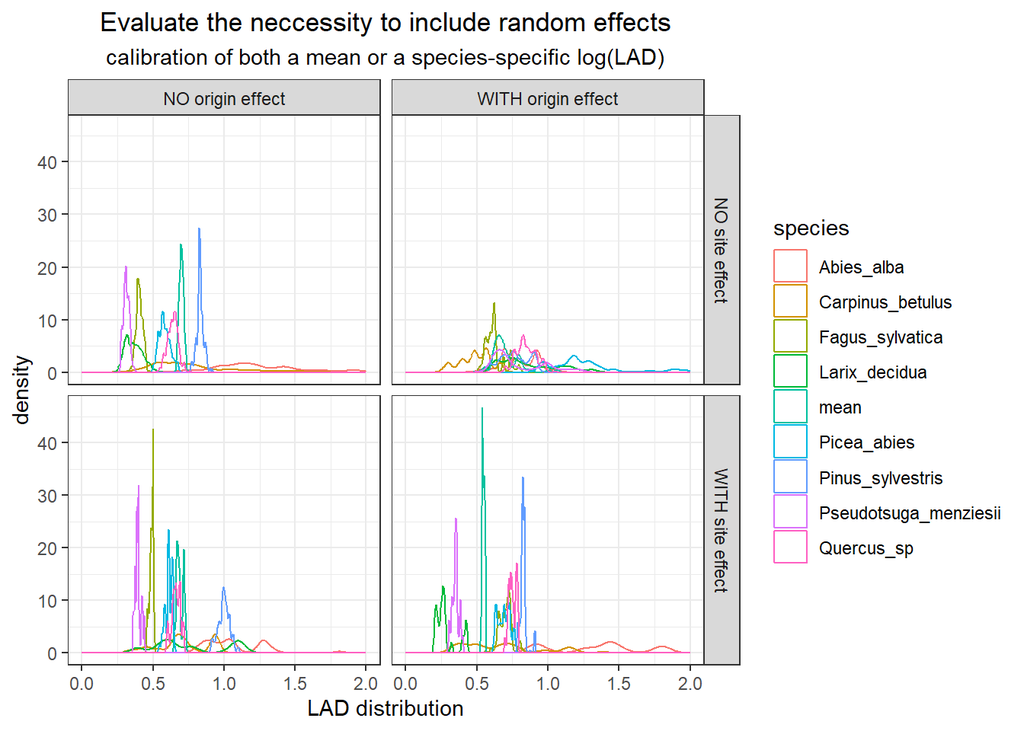

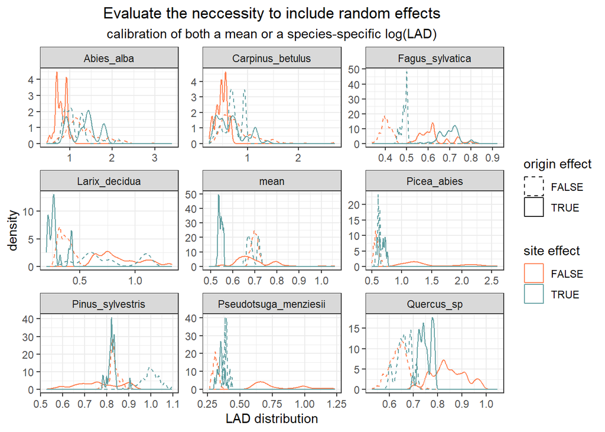

### Observe convergence

#### For a mean species

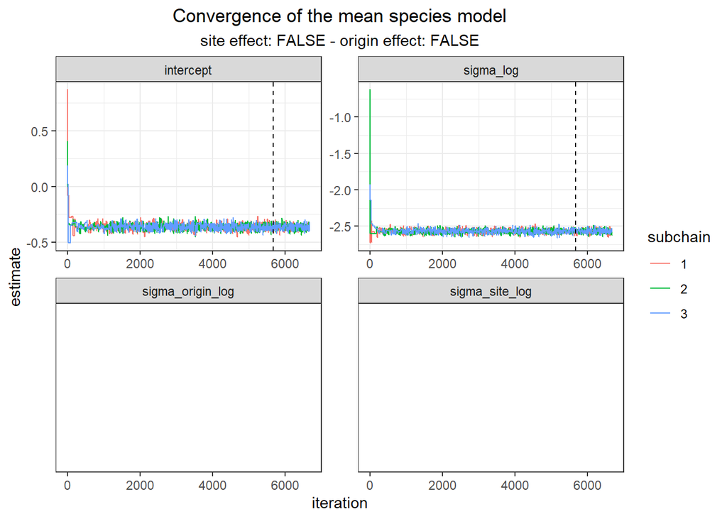

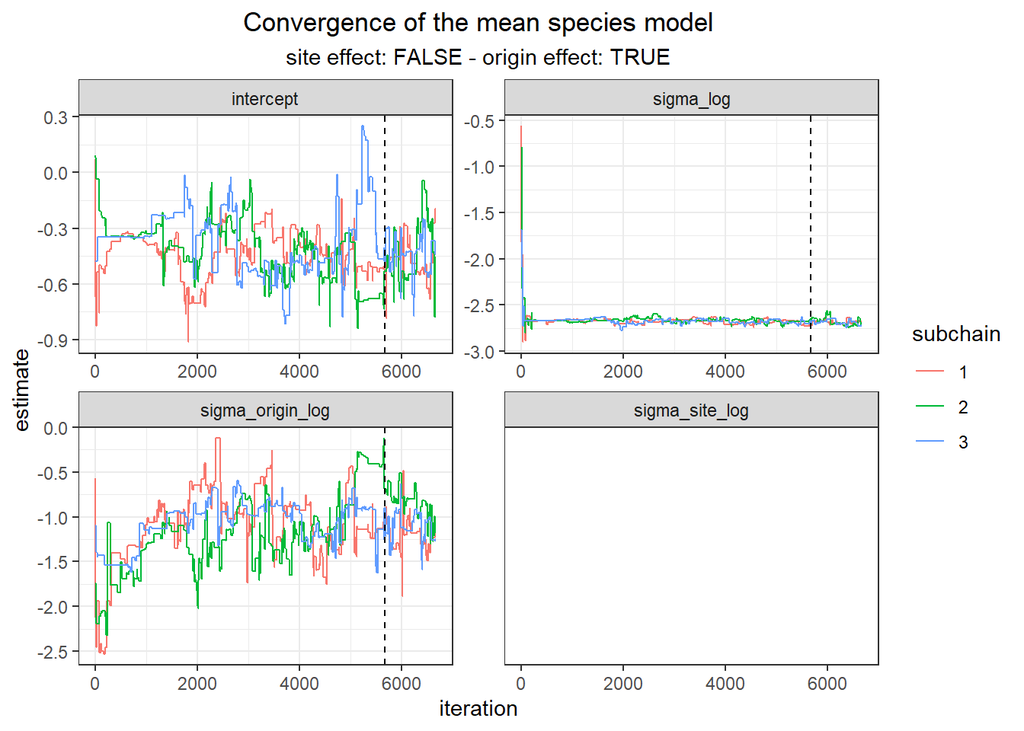

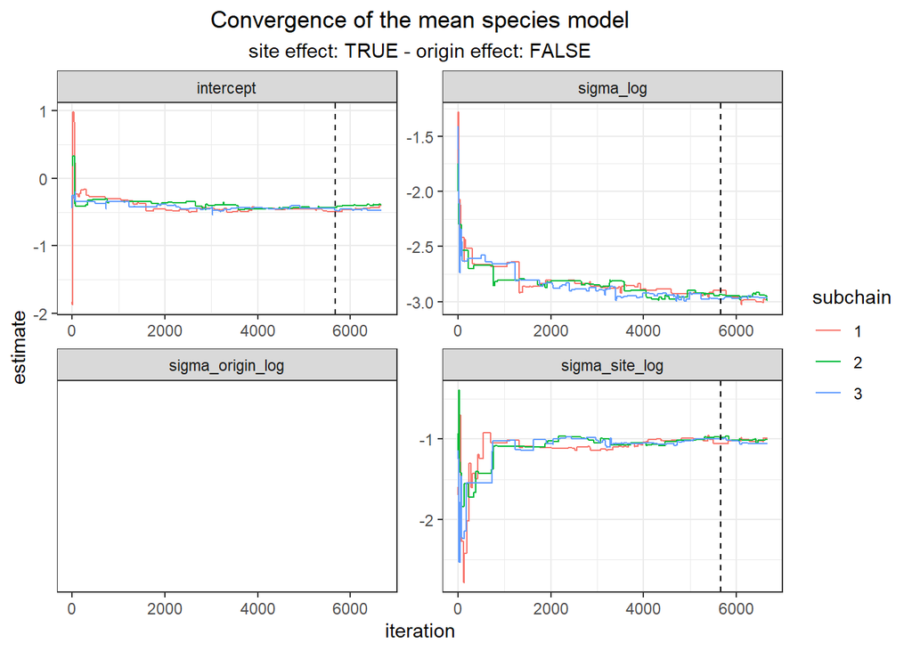

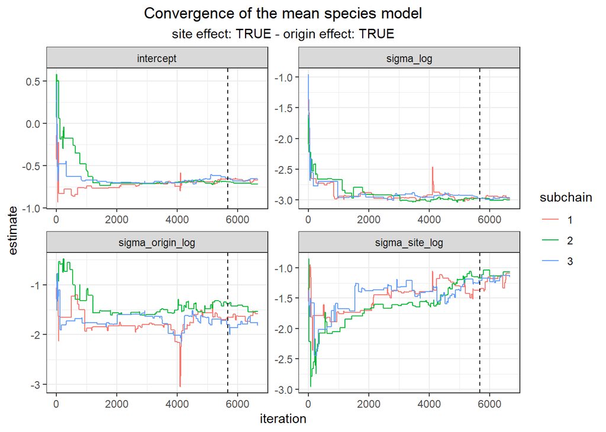

#### Species specific

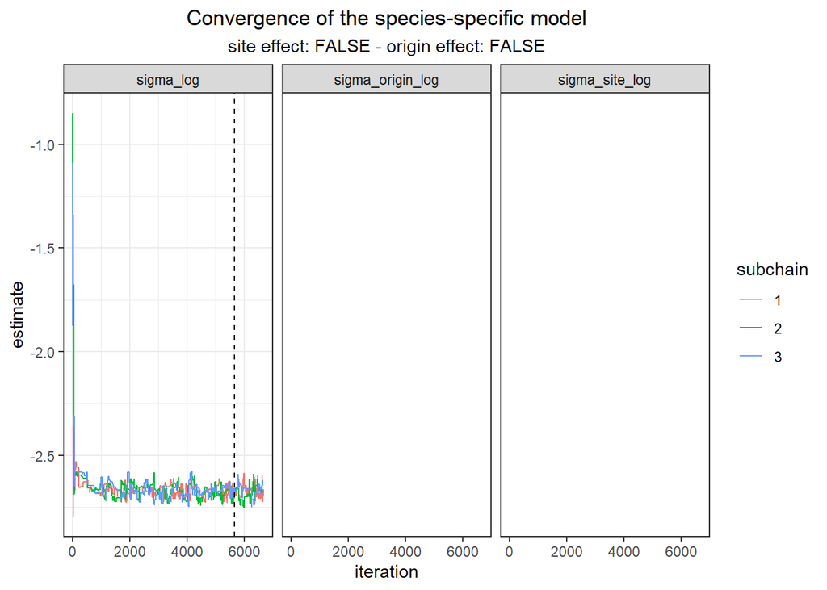

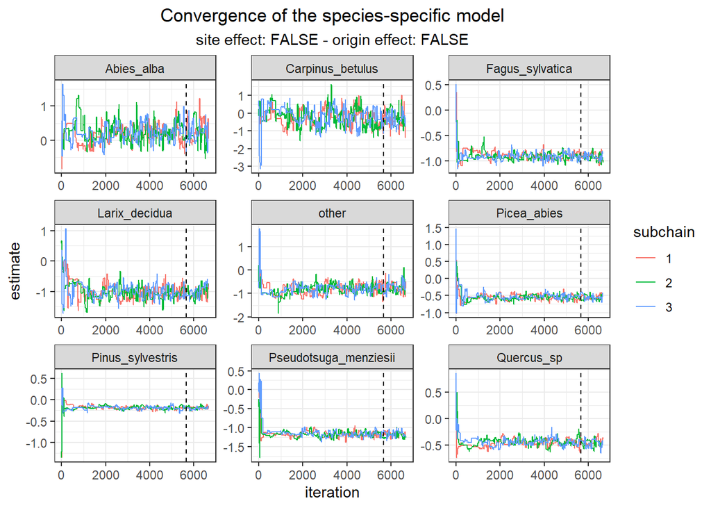

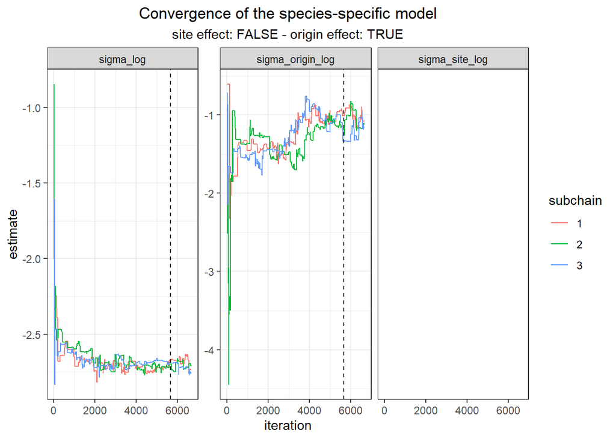

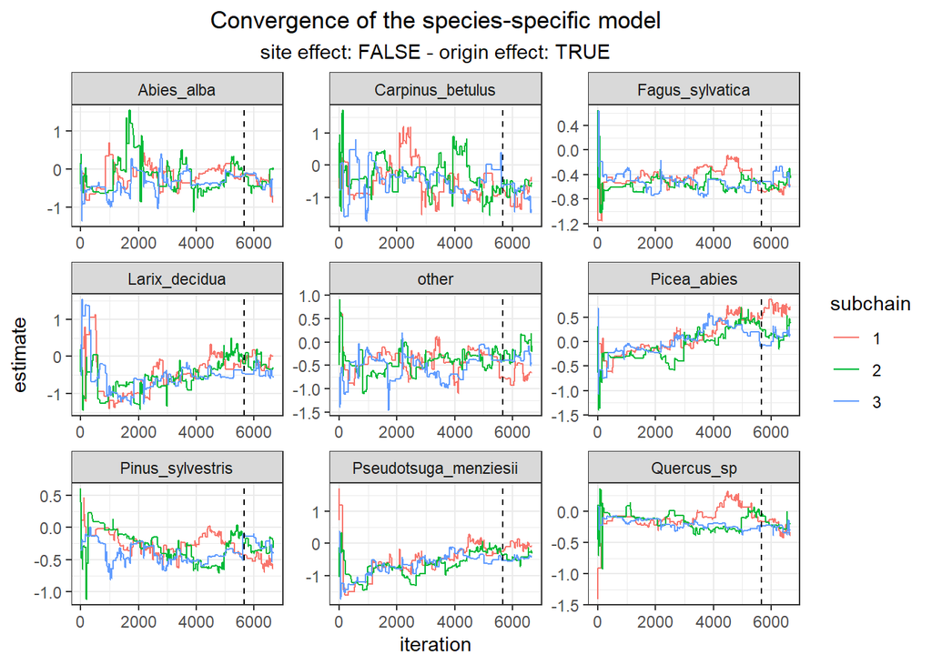

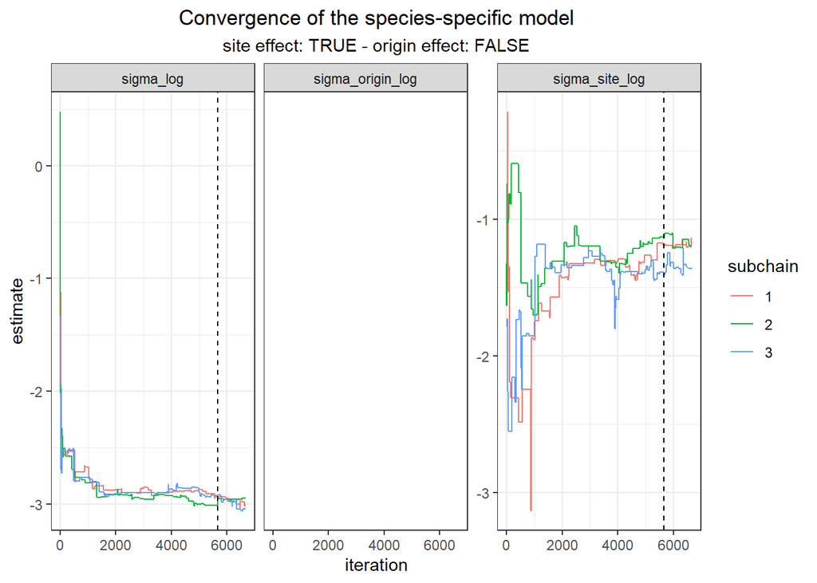

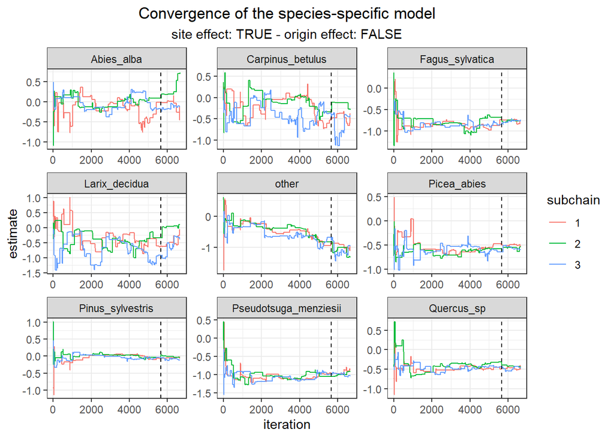

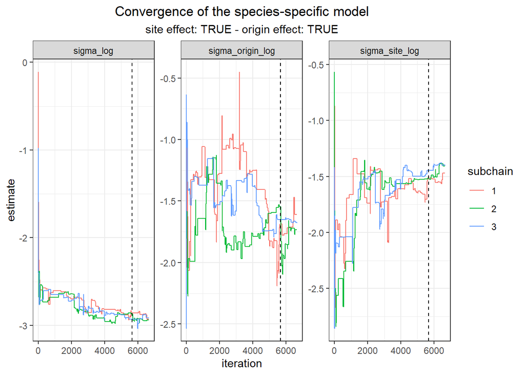

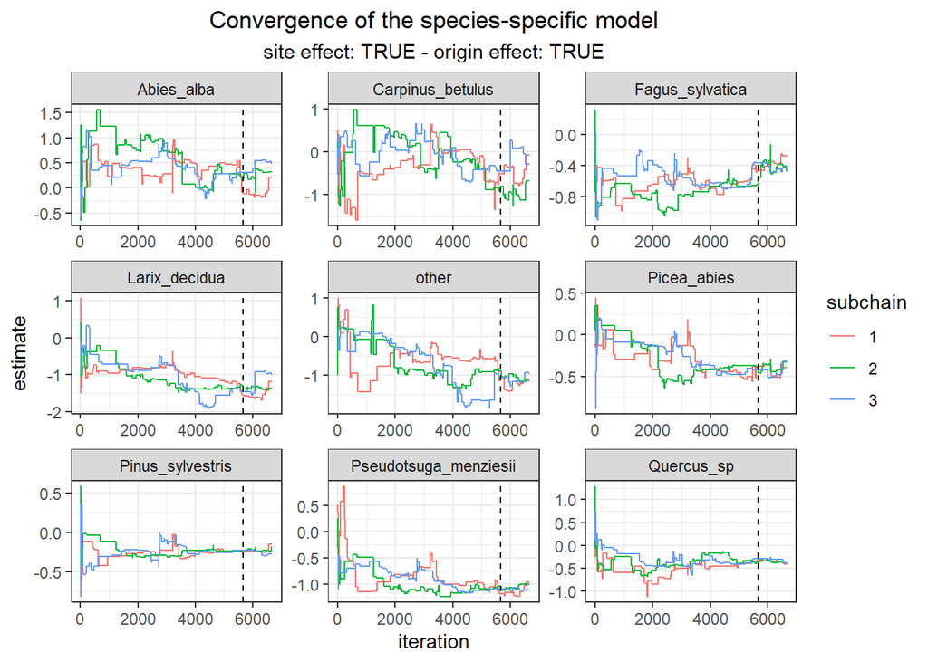

## Experience 3: is there an effect of tree diameter ?